# Introduction

In this notebook we'll learn how to use NumPy to work with numerical data.

[figure not shown]

# Import Statements

```python
import numpy as np

import matplotlib.pyplot as plt
from skimage import data
from PIL import Image # for reading image files
```

# Understanding NumPy's ndarray

NumPy's most amazing feature is the **powerful** ndarray.

[figure not shown]

#### 1-Dimensional Arrays (Vectors)

```python
# Create new ndarray from scatch
my_array = np.array([1.1, 9.2, 8.1, 4.7])
```

```python
# Show rows and columns
print(my_array.shape)
```

```
(4,)
```

```python
# Accessing elements by index
print(my_array[2])
```

```
8.1
```

```python
# Shw dimensions of an array
print(my_array.ndim)
```

```
1
```

#### 2-Dimensional Arrays (Matrices)

```python
array_2d = np.array([[1, 2, 3, 9], [5, 6, 7, 8]])
```

```python
print(f'array_2d has {array_2d.ndim} dimensions')
print(f'Its shape is {array_2d.shape}')
print(f'It has {array_2d.shape[0]} rows and {array_2d.shape[1]} columns')
print(array_2d)
```

```
array_2d has 2 dimensions
Its shape is (2, 4)
It has 2 rows and 4 columns
[[1 2 3 9]
 [5 6 7 8]]
```

```python
# Access the 3rd value in the 2nd row
print(array_2d[1, 2])
```

```
7
```

```python
# Access all the values in the first row
print(array_2d[0, :])
```

```
[1 2 3 9]
```

#### N-Dimensional Arrays (Tensors)

**Challenge**:

- How many dimensions does the array below have?
- What is its shape (i.e., how many elements are along each axis)?
- Try to access the value `18` in the last line of code.
- Try to retrieve a 1 dimensional vector with the values `[97, 0, 27, 18]`
- Try to retrieve a (3,2) matrix with the values `[[ 0, 4], [ 7, 5], [ 5, 97]]`

*Hint*: You can use the `:` operator just as with Python Lists.

```python
mystery_array = np.array([[[0, 1, 2, 3],
                           [4, 5, 6, 7]],

                          [[7, 86, 6, 98],
                          [5, 1, 0, 4]],

                          [[5, 36, 32, 48],
                           [97, 0, 27, 18]]])

# Note all the square brackets!
```

```python
# How many dimensions does the array below have?
print(mystery_array.ndim)
```

```
3
```

```python
# What is its shape (i.e., how many elements are along each axis)?
print(f'Its shape is {mystery_array.shape}')
```

```
Its shape is (3, 2, 4)
```

```python
# Try to access the value 18 in the last line of code.
print(mystery_array[2, 1, 3])
```

```
18
```

```python
# Try to retrieve a (3,2) matrix with the values [[ 0, 4], [ 7, 5], [ 5, 97]]
print(mystery_array[:, :, 0])
```

```
[[ 0  4]
 [ 7  5]
 [ 5 97]]
```

# NumPy Mini-Challenges

#### **Challenge 1**: Use [`.arange()`](https://numpy.org/devdocs/reference/generated/numpy.arange.html)to createa a vector `a` with values ranging from 10 to 29. You should get this:

`print(a)`

`[10 11 12 13 14 15 16 17 18 19 20 21 22 23 24 25 26 27 28 29]`

```python
a = np.arange(10, 30)
print(a)
```

```
[10 11 12 13 14 15 16 17 18 19 20 21 22 23 24 25 26 27 28 29]
```

#### **Challenge 2**: Use Python slicing techniques on `a` to:

- Create an array containing only the last 3 values of `a`
- Create a subset with only the 4th, 5th, and 6th values
- Create a subset of `a` containing all the values except for the first 12 (i.e., `[22, 23, 24, 25, 26, 27, 28, 29]`)
- Create a subset that only contains the even numbers (i.e, every second number)

```python
last_3 = a[-3:]
print(last_3)
```

```
[27 28 29]
```

```python
values_4_5_6 = a[3:6]
print(values_4_5_6)
```

```
[13 14 15]
```

```python
after_12 = a[12:]
print(after_12)
```

```
[22 23 24 25 26 27 28 29]
```

```python
even_array = a[::2]
print(even_array)
```

```
[10 12 14 16 18 20 22 24 26 28]
```

#### **Challenge 3**:Reverse the order of the values in `a`, so that the first element comes last:

`[29, 28, 27, 26, 25, 24, 23, 22, 21, 20, 19, 18, 17, 16, 15, 14, 13, 12, 11, 10]`

If you need a hint, you can check out this part of the [NumPy beginner's guide](https://numpy.org/devdocs/user/absolute_beginners.html#how-to-reverse-an-array)

```python
reverse = np.flip(a)
print(reverse)
```

```
[29 28 27 26 25 24 23 22 21 20 19 18 17 16 15 14 13 12 11 10]
```

#### **Challenge 4**: Print out all the indices of the non-zero elements in this array: [6,0,9,0,0,5,0]

```python
array = np.array([6,0,9,0,0,5,0])
nz_indices = np.nonzero(array)
print(nz_indices)
```

```
(array([0, 2, 5]),)
```

#### **Challenge 5**: Use NumPy to generate a 3x3x3 array with random numbers

Hint: Use the [`.random()` function](https://numpy.org/doc/stable/reference/random/index.html?highlight=random#module-numpy.random)

```python
tensor = np.random.random((3,3,3))
print(tensor)
```

```
[[[0.9142873  0.0274171  0.44318156]
  [0.48961566 0.07997529 0.28693556]
  [0.75430685 0.35451968 0.21397712]]

 [[0.22325548 0.81448859 0.67496567]
  [0.55222985 0.00113654 0.1386636 ]
  [0.56525573 0.42898162 0.26930199]]

 [[0.66193063 0.23413872 0.74997957]
  [0.61588935 0.17721538 0.42112452]
  [0.96576824 0.22316779 0.15243915]]]
```

#### **Challenge 6**: Use [`.linspace()`](https://numpy.org/doc/stable/reference/generated/numpy.linspace.html) to create a vector `x` of size 9 with values spaced out evenly between 0 to 100 (both included).

```python
x = np.linspace(0, 100, 9, endpoint=True)
print(x)
```

```
[  0.   12.5  25.   37.5  50.   62.5  75.   87.5 100. ]
```

#### **Challenge 7**: Use [`.linspace()`](https://numpy.org/doc/stable/reference/generated/numpy.linspace.html) to create another vector `y` of size 9 with values between -3 to 3 (both included). Then plot `x` and `y` on a line chart using Matplotlib.

```python
y = np.linspace(-3, 3, 9, endpoint=True)
print(y)
```

```
[-3.   -2.25 -1.5  -0.75  0.    0.75  1.5   2.25  3.  ]
```

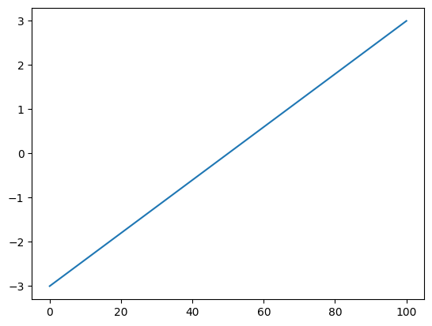

```python
plt.plot(x, y)
plt.show()
```

#### **Challenge 8**: Use NumPy to generate an array called `noise` with shape 128x128x3 that has random values. Then use Matplotlib's [`.imshow()`](https://matplotlib.org/3.1.1/api/_as_gen/matplotlib.pyplot.imshow.html) to display the array as an image.

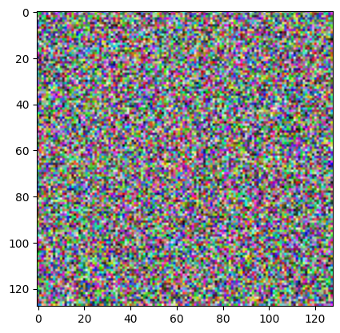

```python
noise = np.random.random((128, 128, 3))
plt.imshow(noise)
plt.show()
```

# Linear Algebra with Vectors

```python
v1 = np.array([4, 5, 2, 7])
v2 = np.array([2, 1, 3, 3])
print(v1+v2)
```

```
[ 6  6  5 10]
```

```python
# Python Lists vs ndarrays
list1 = [4, 5, 2, 7]
list2 = [2, 1, 3, 3]
print(list1+list2)
```

```
[4, 5, 2, 7, 2, 1, 3, 3]
```

```python
print(v1*v2)
```

```
[ 8  5  6 21]
```

```python
# print(TypeError(list1*list2))
```

# Broadcasting and Scalars

```python
array_2d = np.array([[1, 2, 3, 4],
                     [5, 6, 7, 8]])
```

```python
array_2d + 10
```

```
array([[11, 12, 13, 14],
       [15, 16, 17, 18]])
```

```python
array_2d * 5
```

```
array([[ 5, 10, 15, 20],
       [25, 30, 35, 40]])
```

# Matrix Multiplication with @ and .matmul()

[figure not shown]

```python
a1 = np.array([[1, 3],
               [0, 1],
               [6, 2],
               [9, 7]])

b1 = np.array([[4, 1, 3],
               [5, 8, 5]])

print(f'{a1.shape}: a has {a1.shape[0]} rows and {a1.shape[1]} columns.')
print(f'{b1.shape}: b has {b1.shape[0]} rows and {b1.shape[1]} columns.')
print('Dimensions of result: (4x2)*(2x3)=(4x3)')
```

```
(4, 2): a has 4 rows and 2 columns.
(2, 3): b has 2 rows and 3 columns.
Dimensions of result: (4x2)*(2x3)=(4x3)
```

**Challenge**: Let's multiply `a1` with `b1`. Looking at the wikipedia example above, work out the values for c12 and c33 on paper. Then use the [`.matmul()`](https://numpy.org/doc/stable/reference/generated/numpy.matmul.html) function or the `@` operator to check your work.

```python
c = np.matmul(a1, b1)
print(c)
```

```
[[19 25 18]
 [ 5  8  5]
 [34 22 28]
 [71 65 62]]
```

# Manipulating Images as ndarrays

```python
img = data.cat()
```

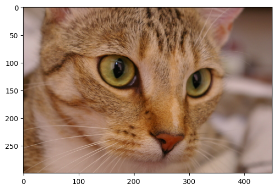

```python
plt.imshow(img)
plt.show()
```

**Challenge**: What is the data type of `img`? Also, what is the shape of `img` and how many dimensions does it have? What is the resolution of the image?

```python
print(type(img))
```

```
<class 'numpy.ndarray'>
```

```python
print(f'img has {img.ndim} dimensions')
print(f'Its shape is {img.shape}')
```

```
img has 3 dimensions
Its shape is (300, 451, 3)
```

```python
print(img)
```

```
[[[143 120 104]
  [143 120 104]
  [141 118 102]
  ...
  [ 45  27  13]
  [ 45  27  13]
  [ 45  27  13]]

 [[146 123 107]
  [145 122 106]
  [143 120 104]
  ...
  [ 46  29  13]
  [ 45  29  13]
  [ 47  30  14]]

 [[148 126 112]
  [147 125 111]
  [146 122 109]
  ...
  [ 48  28  17]
  [ 49  29  18]
  [ 50  30  19]]

 ...

 [[ 92  58  30]
  [105  71  43]
  [132  98  71]
  ...
  [172 145 138]
  [172 145 138]
  [172 145 138]]

 [[128  92  60]
  [139 103  71]
  [134  95  64]
  ...
  [166 142 132]
  [166 142 132]
  [167 143 133]]

 [[139 103  71]
  [127  88  57]
  [125  86  53]
  ...
  [161 137 127]
  [161 137 127]
  [162 138 128]]]
```

**Challenge**: Convert the image to black and white. The values in our `img` range from 0 to 255.

- Divide all the values by 255 to convert them to sRGB, where all the values are between 0 and 1.
- Next, multiply the sRGB array by the `grey_vals` to convert the image to grey scale.
- Finally use Matplotlib's [`.imshow()`](https://matplotlib.org/3.1.1/api/_as_gen/matplotlib.pyplot.imshow.html) together with the colormap parameter set to gray `cmap=gray` to look at the results.

```python
grey_vals = np.array([0.2126, 0.7152, 0.0722])
```

```python
cat_black_gray = np.matmul(img, grey_vals)
```

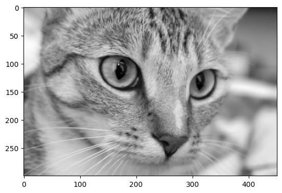

```python
plt.imshow(cat_black_gray, cmap='gray')
plt.show()
```

**Challenge**: Can you manipulate the images by doing some operations on the underlying ndarrays? See if you can change the values in the ndarray so that:

1. You flip the grayscale image upside down

[figure not shown]

2. Rotate the colour image

[figure not shown]

3. Invert (i.e., solarize) the colour image. To do this you need to converting all the pixels to their "opposite" value, so black (0) becomes white (255).

[figure not shown]

#### Challenge Solutions

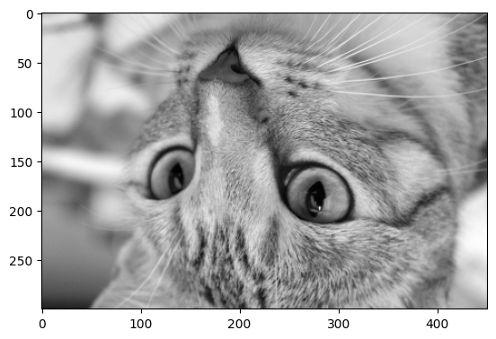

```python
flipped_cat = np.flip(cat_black_gray)
plt.imshow(flipped_cat, cmap='gray')
plt.show()
```

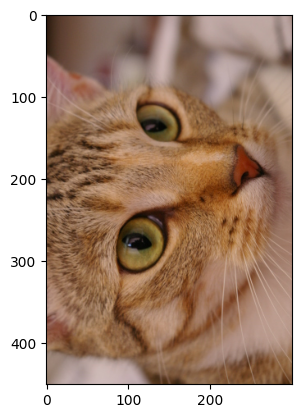

```python
rotate_cat = np.rot90(img)
plt.imshow(rotate_cat)
plt.show()
```

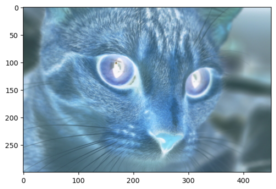

```python
inverse_cat = 255 - img
plt.imshow(inverse_cat)
plt.show()
```

# Use your Own Image!

```python
file_name = 'yummy_macarons.jpg'
my_img = Image.open(file_name)
img_array = np.array(my_img)
```

```python
print(img_array.ndim)
```

```
3
```

```python
print(img_array.shape)
```

```
(533, 799, 3)
```

#### Use PIL to open

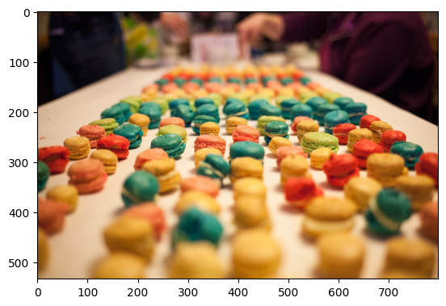

```python
plt.imshow(img_array)
plt.show()
```